# L5

# Improving CSPs

## Filtering

### Arc Consistency

- Arc $X\to{Y}$ is consistent ⟹ for every x in the tail, there is some y in the head which could be assigned without violating a constraint
- Arcs go in each direction

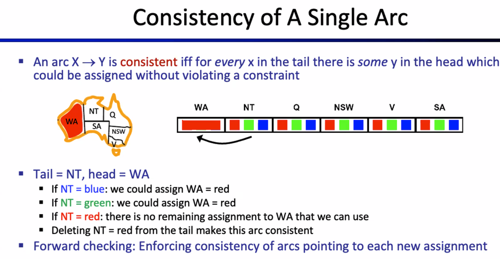

- Screenshot_2023-09-07_at_5.24.50_PM.png

- If we change something to enforce consistency, we have to recheck all arcs to and from that updated value
- $O(n^{2}d^{3})$ but can be reduced to $O(n^{2}d^{2})$
  - $n\coloneqq{\text{number of arcs}}$
  - $d\coloneqq{|D|}\big\vert_{D\,\coloneqq\,{\mathrm{domain}}}$
  - Poly time instead of exponential time
- AC-3

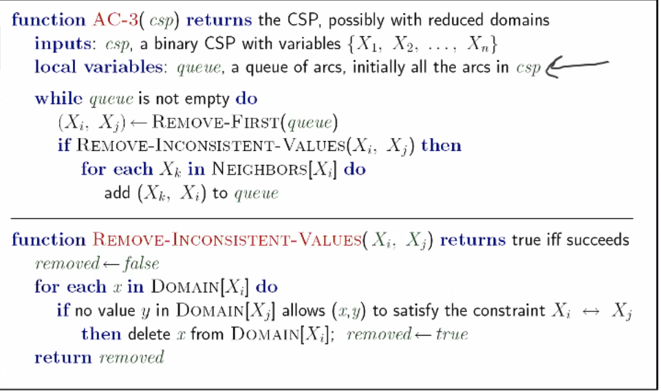

  - Can be run inside of backtracking to enforce consistency of an entire CSP
- May result in an undefined state (no explicit solutions or none at all)

### K-Consistency (Out of Scope)

- Increasing degrees of consistency
  - 1-consistency (node consistency) ≔ each single node’s domain $D$ has a value which meets that node’s unary constraints
  - 2-consistency (arc consistency) ≔ for each pair of nodes, any consistent assignment to one can be extended to the other
  - K-consistency ≔ for each $k$ nodes, any consistent assignment to k-1 can be extended to the $k^{\mathrm{th}}$ node.
- Strong consistency ≔ $n$-consistent ∀ $n\in{k}$

## Ordering

- Probably have to run some filtering after making a choice to see if the assignment is easy or hard

### Minimum Remaining Values (MRV)

- Used for variable ordering
- Choose the variable with the fewest legal left values in its domain $D$
- AKA ‘most constrained variable’ or ‘fast-fail ordering’

## Structuring

- Independent subproblems are identifiable as connected components of a constraint graph
  - Solve independent problems
- Generally there aren’t independent subproblems in a CSP
  - We choose CSPs based off of conflicting variables
- Can have incredibly big affect on runtime

### Tree-Structured CSPs

- Theorem: if the constraint graph has no loops, the CSP can be solved in $O(nd^{2})$

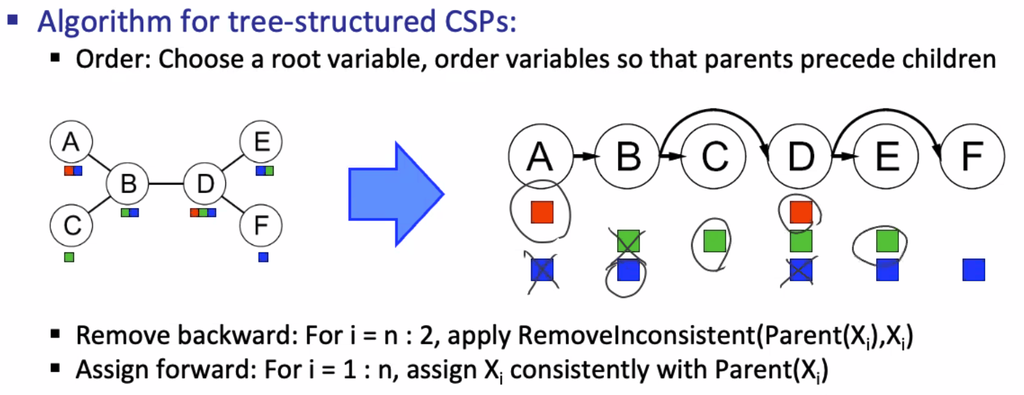

- Screenshot_2023-09-07_at_6.10.04_PM.png

- Always works for all trees but not for SCCs because backtracking
- $O(nd^{2})$

### Cutset Conditioning

- Remove a cutset, instantiate the cutset, and compute residual CSP for each assignment
- $O((d^{c})(n-c)(d^{2}))$
  - Very fast for small c
- Finding the cutset can be hard

## Iterative Improvement

- Local search methods typically work with ‘complete’ states (all variables assigned)
- Idea: take a random assignment with unsatisfied constraints and attempt to *fix* the problems
- No fringe

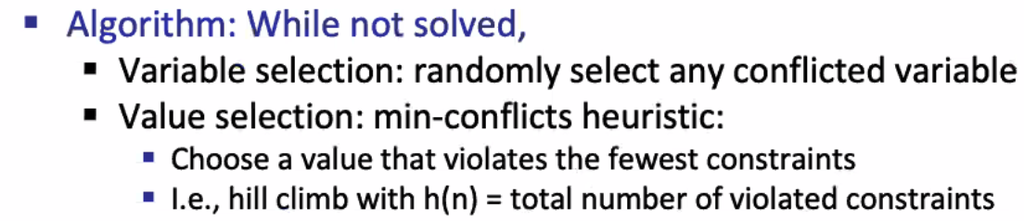

- Screenshot_2023-09-07_at_6.21.18_PM.png

- No guarantee of correctness
- Tends to be close to $O(1)$ for CSPs except in a narrow ‘critical range’ $R$
  - $R\coloneqq\frac{\text{number of constraints}}{\text{number of variables}}$
  - Most CSPs are in that critical range 😭

#### Local Search

- Improve a single option until you can’t make it better (no fringe)
- Generalized iterative improvement to search problems

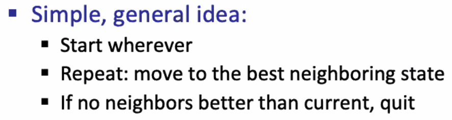

- Screenshot_2023-09-07_at_6.28.11_PM.png

- Not necessarily complete or optimal
- Finds a local max instead of a global max
- Can be optimized with simulated annealing or genetic search